# Genome-wide LCL co-accessibility adjusted for donor

Crystal Shan

# Adjust for donor effect in co-accessibility analysis using logisitc regression

whether, within a donor, fibers where CRE1 is open are more likely to have CRE2 open?

Samples are first summed within the existing `donor`

For each donor, two grouped-binomial rows represent all shared reads:

| CRE1 status `x` | CRE2 open `y1` | CRE2 closed `y0` |
| --- | --- | --- |
| 0 | `CRE2_access` | `co_closed` |
| 1 | `co_access` | `CRE1_access` |

## Fit the model

`LCL_run_v3_donor_log_reg.sh` runs `LCL_fit_v3_donor_log_reg.R`

```bash
cd /project/spott/cshan/fiber-seq/code/co-accessibility/LCL

# genome-wide -> coaccess/donor_adjusted/all_chr/ and coaccess/donor_adjusted/noXCI/
sbatch LCL_run_v3_donor_log_reg.sh
```

The job runs two analyses

- Run A (`all_chr`): all chromosomes and all donors
- Run B (`noXCI`): same, but exclude female chrX samples (chrX uses male samples only)

and writes `coaccess/donor_adjusted/<analysis>/LCL_coaccess_pairs_donor_adjusted_<analysis>.tsv.gz`

#### Aggregate by donor

sums the four cell counts within each (CRE_pair, chrom, donor) group

- donor_all uses every sample on every chr
- donor_male_x keeps only chrX rows from samples with male

## Fit the regression model

For every CRE pair, the model asks whether CRE2 being open on a fiber depends on CRE1 being open, after accounting for which donor the fiber came from.

Each read (fiber) covering both CREs has two binary outcomes: whether CRE1 is open (x) and whether CRE2 is open (y). The model is a logistic regression with CRE2 as the response: **logit P(CRE2 open) = donor + beta x (x)**

- donor is a separate intercept for each donor - donor’s baseline log-odds that CRE2 is open when CRE1 is closed
- beta is a coefficient shared across all donors. It is the change in log-odds of CRE2 being open when CRE1 is open, within a donor
- the reported odds ratio is OR_adj = exp(beta)

x is the CRE1 accessibility status of a fiber: a binary indicator

- x = 1 means CRE1 is open on that fiber
- x = 0 means CRE1 is closed on that fiber

**Coverage filter**: a pair is tested only if at least 20 fibers span both CREs (summed over all samples in the analysis; chrX in `noXCI` counts male samples only). The pooled Fisher test and `noXCI` use the same rule for their BH family.

**Separated pairs are removed** (not tested, no OR, no p-value)

- Positive separation: every donor has CRE1_access == 0 or CRE2_access == 0
- Negative separation: every donor has co_access == 0 or co_closed == 0
- with separation the full model has no finite maximum (beta goes to infinity), so there is no MLE and no LRT

Null model: CRE2 depends only on donor (no CRE1 effect, β = 0). Full model: CRE2 depends on donor and CRE1 (β is estimated).

Each model has a likelihood

**LRT (likelihood ratio test)** fit both null and full model, then compare how good is each one 1. find the max for the null model 2. find the max for the full model 3. how much bigger is the max for full model

`fit_pair()` in `stats_testing_functions.r`: anova(null, full, test = “LRT”)

- MLE (maximum likelihood estimate) is the ordinary logistic-regression estimate of the odds ratio, and select beta that best fits the data
- BH family = pairs that pass the coverage filter, have at least one informative donor and are not separated

## Load the fitted results

```r
output_base <- file.path(params$root, "coaccess", "donor_adjusted")
output_dir <- if (is.null(params$chrom)) output_base else
  file.path(output_base, "smoke_tests", params$chrom)
result_sets <- list()
for (a in c("all_chr", "noXCI")) {
  path <- file.path(output_dir, a, paste0("LCL_coaccess_pairs_donor_adjusted_", a, ".tsv.gz"))
  if (!file.exists(path)) stop("Missing ", path, "; submit LCL_run_v3_donor_log_reg.sh first")
  result_sets[[a]] <- fread(path)
  cat(a, ":", nrow(result_sets[[a]]), "rows <-", path, "\n")
}
```

```
## all_chr : 248879 rows <- /project/spott/cshan/fiber-seq/LCL_project/co-accessibility/coaccess/donor_adjusted/all_chr/LCL_coaccess_pairs_donor_adjusted_all_chr.tsv.gz
## noXCI : 248855 rows <- /project/spott/cshan/fiber-seq/LCL_project/co-accessibility/coaccess/donor_adjusted/noXCI/LCL_coaccess_pairs_donor_adjusted_noXCI.tsv.gz
```

```r
fdr_scope <- unique(result_sets$all_chr$fdr_scope)

pooled <- fread(file.path(params$root, "coaccess", "LCL_coaccess_pairs.tsv.gz"),
                select = c("CRE_pair", "OR", "fdr", "n_shared_reads", "co_access", "expected_co_access"))
top10_genome_wide <- copy(pooled[!is.na(fdr) & fdr < 0.05 & !is.na(OR) & OR > 1 &
                          co_access > expected_co_access])
setorderv(top10_genome_wide, c("fdr", "OR", "n_shared_reads", "CRE_pair"), c(1L, -1L, -1L, 1L))
top10_genome_wide <- head(top10_genome_wide, 10L)[, .(CRE_pair, pooled_rank = seq_len(.N))]
```

# Summary

positive association filter is `fdr_adj < 0.05 & OR_adj > 1 & co_access > expected_co_access_adj`

builds summary tables from the fitted results

- `significance_summary`: compares the new adjusted analysis against the old pooled one, and count how many are significant in both

```r
significance_summary <- rbindlist(lapply(names(result_sets), function(a) {
  d <- copy(result_sets[[a]])
  d[, adjusted_positive := !is.na(fdr_adj) & fdr_adj < 0.05 & !is.na(OR_adj) &
      OR_adj > 1 & !is.na(expected_co_access_adj) & co_access > expected_co_access_adj]
  d[, pooled_positive := !is.na(fdr_pooled) & fdr_pooled < 0.05 & OR_pooled > 1 &
      co_access_pooled > expected_co_access_pooled]
  rbindlist(lapply(c("all", "chrX"), function(region) {
    z <- if (region == "chrX") d[chrom == "chrX"] else d
    data.table(analysis = a, region = region, n_pairs = nrow(z),
      low_coverage_removed = sum(z$fit_status == "low_coverage"),
      separated_removed = sum(z$fit_status %in% c("separation_positive", "separation_negative")),
      n_tested = sum(is.finite(z$p_adj_one_sided)),
      adjusted_positive = sum(z$adjusted_positive), pooled_positive = sum(z$pooled_positive),
      overlap_positive = sum(z$adjusted_positive & z$pooled_positive))
  }))
}))

top10 <- rbindlist(lapply(result_sets, function(d) d[!is.na(adjusted_rank) & adjusted_rank <= 10L]))
setorder(top10, analysis, adjusted_rank)
top10_genome_wide_adjusted <- rbindlist(lapply(names(result_sets), function(a) {
  d <- merge(top10_genome_wide, result_sets[[a]], by = "CRE_pair", all.x = TRUE, sort = FALSE)
  d[, analysis := a]
  d[, comparison_status := fifelse(is.na(fit_status), "outside_chromosome_scope", "in_scope")]
  setorder(d, pooled_rank)
  d
}), fill = TRUE)

print(significance_summary)
```

```
##    analysis region n_pairs low_coverage_removed separated_removed n_tested
##      <char> <char>   <int>                <int>             <int>    <int>
## 1:  all_chr    all  248879                 2358             40852   172815
## 2:  all_chr   chrX    5430                   45              1011     3754
## 3:    noXCI    all  248855                 2558             41111   171643
## 4:    noXCI   chrX    5406                  245              1270     2582
##    adjusted_positive pooled_positive overlap_positive
##                <int>           <int>            <int>
## 1:              3588            3332             2332
## 2:               433             434              330
## 3:              2903            3332             1944
## 4:                12             434                9
```

```r
print(top10[, .(analysis, adjusted_rank, CRE_pair, chrom, gene_names, OR_adj,
  OR_adj_ci_low, OR_adj_ci_high, fdr_adj, fit_status, or_method)])
```

```
##     analysis adjusted_rank
##       <char>         <int>
##  1:  all_chr             1
##  2:  all_chr             2
##  3:  all_chr             3
##  4:  all_chr             4
##  5:  all_chr             5
##  6:  all_chr             6
##  7:  all_chr             7
##  8:  all_chr             8
##  9:  all_chr             9
## 10:  all_chr            10
## 11:    noXCI             1
## 12:    noXCI             2
## 13:    noXCI             3
```

[output cut: 81 more lines]

```r
cat("Original pooled top-ten rankings after donor adjustment:\n")
```

```
## Original pooled top-ten rankings after donor adjustment:
```

```r
print(top10_genome_wide_adjusted[, .(analysis, pooled_rank, CRE_pair, adjusted_rank,
                            OR_adj, fdr_adj, fit_status, comparison_status)])
```

```
##     analysis pooled_rank
##       <char>       <int>
##  1:  all_chr           1
##  2:  all_chr           2
##  3:  all_chr           3
##  4:  all_chr           4
##  5:  all_chr           5
##  6:  all_chr           6
##  7:  all_chr           7
##  8:  all_chr           8
##  9:  all_chr           9
## 10:  all_chr          10
## 11:    noXCI           1
## 12:    noXCI           2
## 13:    noXCI           3
```

[output cut: 57 more lines]

```r
summary_dir <- file.path(output_dir, "summary")
dir.create(summary_dir, recursive = TRUE, showWarnings = FALSE)
for (entry in list(c("significance_summary", "significance_comparison.tsv"),
                  c("top10", "new_top10.tsv"), c("top10_genome_wide_adjusted", "old_pooled_top10_adjusted.tsv")))
  fwrite(get(entry[1]), file.path(summary_dir, entry[2]), sep = "\t", na = "NA")
```

### Summary plot of logistic regression with donor effects

1. Pooled vs donor-adjusted odds ratio: how much did donor adjustment change the effect sizes?
2. QQ plot of the p-values: are the p-values well calibrated?

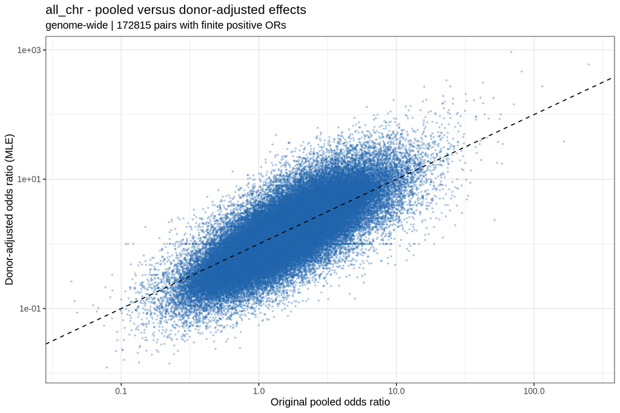

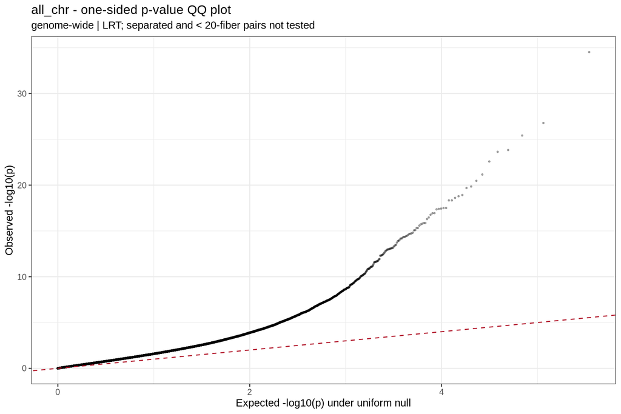

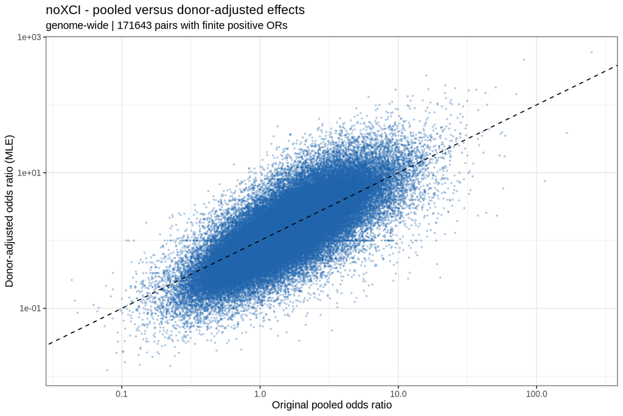

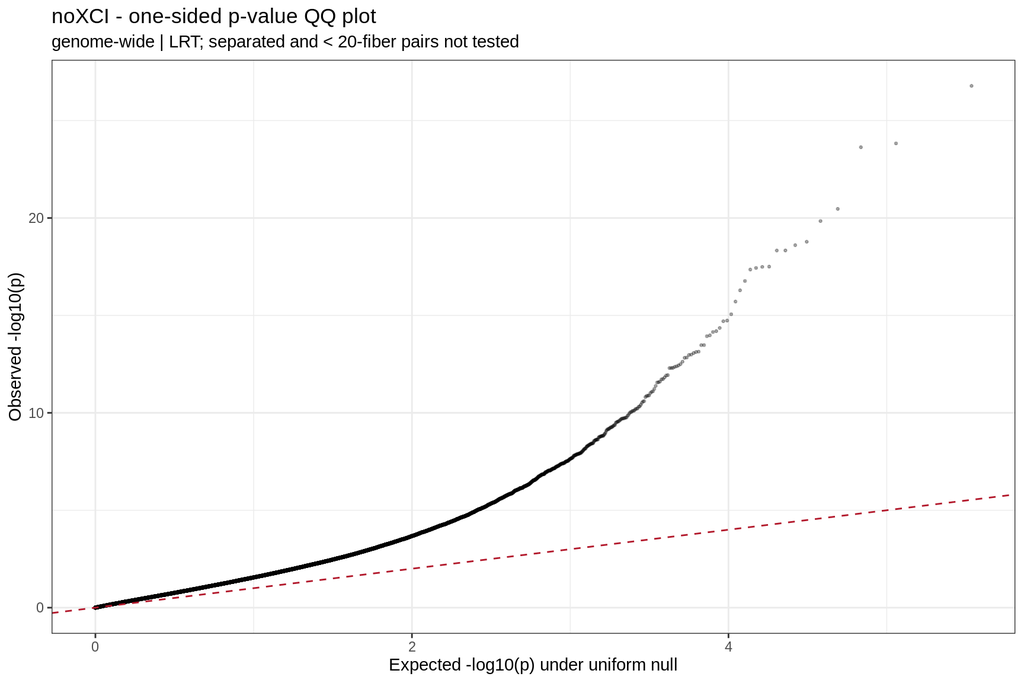

```r
for (a in names(result_sets)) {
  d <- result_sets[[a]]
  plot_data <- d[is.finite(OR_pooled) & OR_pooled > 0 & is.finite(OR_adj) & OR_adj > 0]
  p <- ggplot(plot_data, aes(OR_pooled, OR_adj)) +
    geom_point(size = 0.45, alpha = 0.25, colour = "#2166AC") + geom_abline(slope = 1, intercept = 0, linetype = 2) +
    scale_x_log10() + scale_y_log10() +
    labs(x = "Original pooled odds ratio", y = "Donor-adjusted odds ratio (MLE)",
         title = paste(a, "- pooled versus donor-adjusted effects"),
         subtitle = paste(fdr_scope, "|", nrow(plot_data), "pairs with finite positive ORs")) + theme_bw()
  print(p)
  ggsave(file.path(output_dir, a, "plots", "pooled_vs_adjusted_OR.pdf"), p,
         width = 9, height = 6, create.dir = TRUE)
  pvalues <- sort(d$p_adj_one_sided[is.finite(d$p_adj_one_sided)])
  if (length(pvalues)) {
    qq <- data.table(expected = -log10(ppoints(length(pvalues))),
                     observed = -log10(pmax(pvalues, .Machine$double.xmin)))
    q <- ggplot(qq, aes(expected, observed)) + geom_point(size = 0.5, alpha = 0.3) +
      geom_abline(slope = 1, intercept = 0, linetype = 2, colour = "#B2182B") +
      labs(x = "Expected -log10(p) under uniform null", y = "Observed -log10(p)",
           title = paste(a, "- one-sided p-value QQ plot"),
           subtitle = paste(fdr_scope, "| LRT; separated and < 20-fiber pairs not tested")) + theme_bw()
    print(q)
    ggsave(file.path(output_dir, a, "plots", "pvalue_QQ.pdf"), q,
           width = 9, height = 6, create.dir = TRUE)
  }
}
```